# Morgan

Topics that will be discussed in this summary report for Morgan County are

- Demographic Characteristics
  - Population growth from 1970 to 2020;
  - population density
  - sex, race, and age
  - educational level of the adult population
  - housing characteristics in terms of age of the housing stock and type of tenure
- Economic Characteristics
  - family income, household income, per capita income,
  - poverty status of families;
  - employment classification according to industry;
  - labor force by place of work and commuting patterns;

For more details on the data used, please see the Data Description tab.

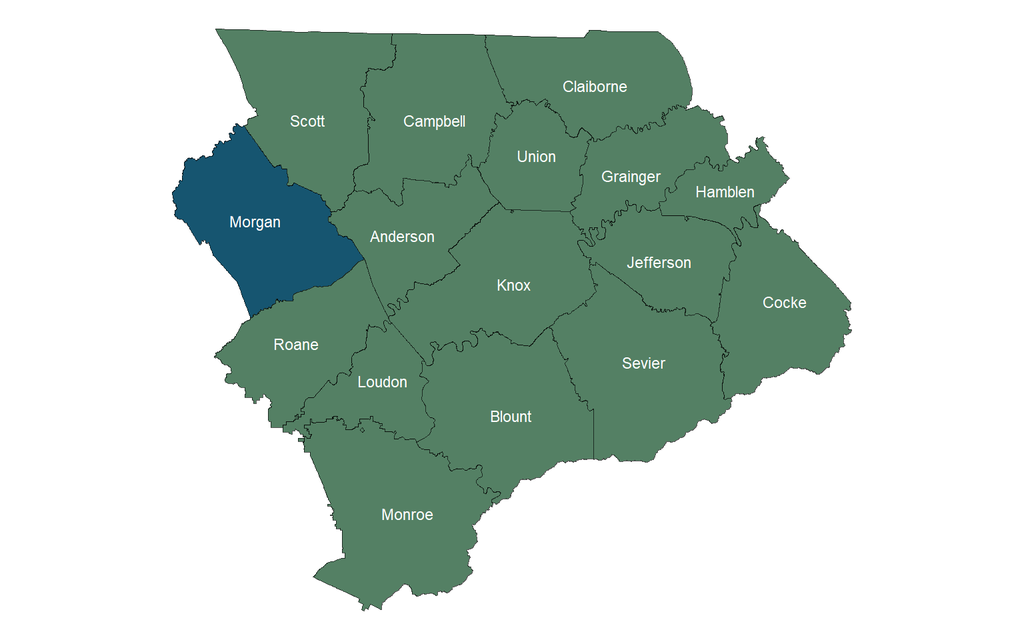

**Population and Growth**

| Place | 1970 | 1980 | 1990 | 2000 | 2010 | 2020 | Change 1970-1980 | Change 1980-1990 | Change 1990-2000 | Change 2000-2010 | Change 2010-2020 |
| --- | --- | --- | --- | --- | --- | --- | --- | --- | --- | --- | --- |
| Morgan County | 13619 | 16604 | 17300 | 19757 | 21987 | 21035 | 2985 | 696 | 2457 | 2230 | -952 |
| Oakdale |  | 323 | 268 | 244 | 212 | 191 |  | -55 | -24 | -32 | -21 |
| Sunbright |  |  |  | 577 | 552 | 519 |  |  |  | -25 | -33 |
| Wartburg |  | 761 | 932 | 890 | 918 | 848 |  | 171 | -42 | 28 | -70 |

[interactive chart not shown]

IPUMS NHGIS, University of Minnesota, www.nhgis.org

**Population Density**

| Place | Area | Population Density |
| --- | --- | --- |
| Morgan County | 522.4029708272044 | 40.26585064532063 |
| Oakdale | 0.896239090258555 | 213.1127754591675 |
| Sunbright | 3.527317424788112 | 147.13731073726 |
| Wartburg | 1.01702991535312 | 833.8004489332732 |

[interactive chart not shown]

source: U. S. Census Bureau *Decennial Census: Redistricting Data (PL 94-171)*, 2020, accessed June 2, 2026, http://api.census.gov/data/2020/dec/pl.

**Population Descriptions**

| Place | Year | Race Category | Number of People | Percentage of People |
| --- | --- | --- | --- | --- |
| Morgan County | 2020 | Black | 971 | 0.04297791351303501 |
| Morgan County | 2020 | Other | 934 | 0.04134023812685345 |
| Morgan County | 2020 | White | 19130 | 0.8467224361527906 |
| Oakdale | 2020 | Black | 0 | 0 |
| Oakdale | 2020 | Other | 13 | 0.0005753994600097375 |
| Oakdale | 2020 | White | 178 | 0.007878546452441022 |
| Sunbright | 2020 | Black | 1 | 4.426149692382596e-05 |
| Sunbright | 2020 | Other | 22 | 0.0009737529323241712 |
| Sunbright | 2020 | White | 496 | 0.02195370247421768 |
| Wartburg | 2020 | Black | 12 | 0.0005311379630859116 |

[output cut: 2 more lines]

| Place | Sex | Age Range | Year | Number of People | Percentage of People |
| --- | --- | --- | --- | --- | --- |
| Morgan County | Female | 10 to 14 years | 2020 | 739 | 0.03117485762497364 |
| Morgan County | Female | 15 to 19 years | 2020 | 581 | 0.02450959713140688 |
| Morgan County | Female | 20 to 24 years | 2020 | 503 | 0.02121915207762076 |
| Morgan County | Female | 25 to 29 years | 2020 | 573 | 0.02417211558742881 |
| Morgan County | Female | 30 to 34 years | 2020 | 499 | 0.02105041130563172 |
| Morgan County | Female | 35 to 39 years | 2020 | 622 | 0.02623919004429445 |
| Morgan County | Female | 40 to 44 years | 2020 | 485 | 0.02045981860367011 |
| Morgan County | Female | 45 to 49 years | 2020 | 667 | 0.02813752372917106 |
| Morgan County | Female | 5 to 9 years | 2020 | 387 | 0.01632566968993883 |
| Morgan County | Female | 50 to 54 years | 2020 | 730 | 0.03079519088799831 |

[output cut: 134 more lines]

[interactive chart not shown]

source: U. S. Census Bureau *Decennial Census: Redistricting Data (PL 94-171)*, 2020, accessed June 2, 2026, http://api.census.gov/data/2020/dec/pl.

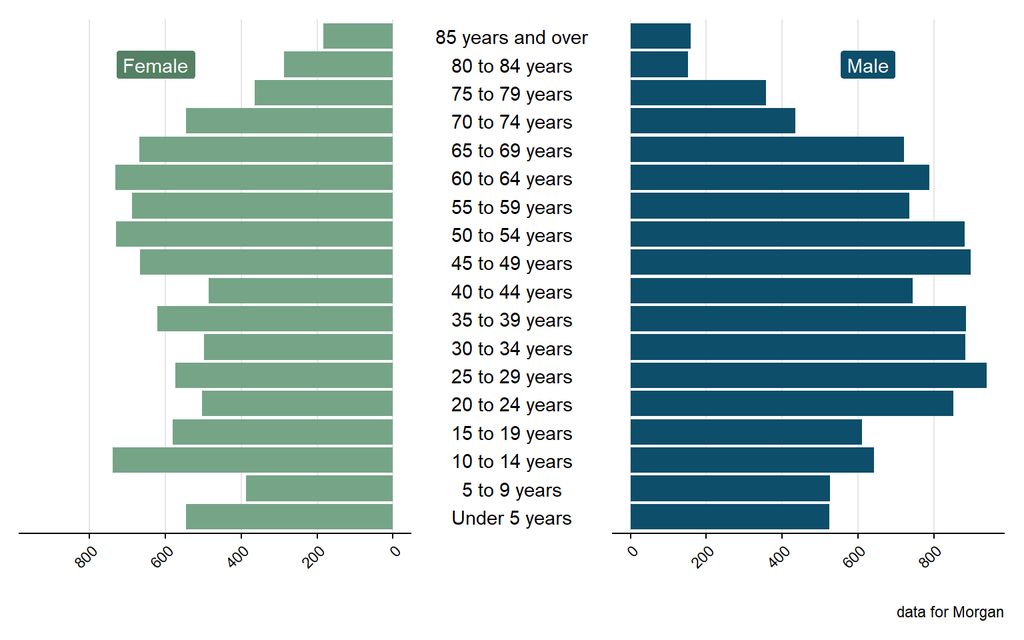

source: U. S. Census Bureau *American Community Survey 5-Year Estimates: Comparison Profiles 5-Year*, 2020, accessed June 2, 2026, http://api.census.gov/data/2020/acs/acs5.

**Education**

| Place | Level of Education | Year | Number of People | Percentage of People |
| --- | --- | --- | --- | --- |
| Morgan County | 9th to 12th Grade, No Diploma | 2010 | 2022 | 0.1235261775306983 |
| Morgan County | Associate's degree | 2010 | 726 | 0.04435212902437535 |
| Morgan County | Bachelor's degree | 2010 | 650 | 0.03970920642678234 |
| Morgan County | Graduate or Professional Degree | 2010 | 302 | 0.01844950821675118 |
| Morgan County | Less Than 9th Grade | 2010 | 1455 | 0.08888753130918199 |
| Morgan County | Some College, No Degree | 2010 | 2393 | 0.1461909707373694 |
| Morgan County | Total | 2010 | 15194 | 0.9282179729977397 |
| Morgan County | 9th to 12th Grade, No Diploma | 2020 | 1722 | 0.1009556193937973 |
| Morgan County | Associate's degree | 2020 | 1105 | 0.06478278712552031 |
| Morgan County | Bachelor's degree | 2020 | 981 | 0.05751304449786011 |

[output cut: 46 more lines]

[interactive chart not shown]

source: U. S. Census Bureau *American Community Survey 5-Year Estimates: Comparison Profiles 5-Year*, 2020, accessed June 2, 2026, http://api.census.gov/data/2020/acs/acs5.

**Housing Units by Year of Construction**

| Place | Year | 1939 or earlier | 1940-1959 | 1960-1979 | 1980 to 1989 | 1990 to 1999 | 2000 to 2004 | 2005 or later | 2000 to 2009 | 2010 or later | Total |
| --- | --- | --- | --- | --- | --- | --- | --- | --- | --- | --- | --- |
| Morgan County | 2010 | 514 | 939 | 2442 | 1647 | 2106 | 836 | 275 |  |  | 8759 |
| Morgan County | 2020 | 748 | 1058 | 2095 | 1413 | 1524 |  |  | 1506 | 711 | 9055 |
| Oakdale | 2010 | 38 | 25 | 36 | 11 | 15 | 13 | 6 |  |  | 144 |
| Sunbright | 2010 | 37 | 32 | 73 | 59 | 28 | 23 | 8 |  |  | 260 |
| Wartburg | 2010 | 22 | 74 | 149 | 95 | 56 | 4 | 25 |  |  | 425 |
| Oakdale | 2020 | 26 | 1 | 24 | 15 | 23 |  |  | 2 | 5 | 96 |
| Sunbright | 2020 | 67 | 50 | 71 | 21 | 37 |  |  | 7 | 19 | 272 |
| Wartburg | 2020 | 16 | 105 | 187 | 118 | 28 |  |  | 12 | 1 | 467 |

[interactive chart not shown]

source: U. S. Census Bureau *Decennial Census: Redistricting Data (PL 94-171)*, 2020, accessed June 2, 2026, http://api.census.gov/data/2020/dec/pl.

**Housing Units by Type of Tenure**

| Place | Year | Own | Rent | Total |
| --- | --- | --- | --- | --- |
| Morgan County | 2010 | 6509 | 1445 | 7954 |
| Morgan County | 2020 | 6201 | 1323 | 7524 |
| Oakdale | 2010 | 99 | 27 | 126 |
| Sunbright | 2010 | 114 | 80 | 194 |
| Wartburg | 2010 | 142 | 209 | 351 |
| Oakdale | 2020 | 59 | 21 | 80 |
| Sunbright | 2020 | 161 | 56 | 217 |
| Wartburg | 2020 | 177 | 241 | 418 |

[interactive chart not shown]

source: U. S. Census Bureau *Decennial Census: Redistricting Data (PL 94-171)*, 2020, accessed June 2, 2026, http://api.census.gov/data/2020/dec/pl.

**Income Comparison**

| Place | Year | Median Family Income | Median Household Income | Per Capita Income |
| --- | --- | --- | --- | --- |
| Morgan County | 2020 | 49173 | 41701 | 20258 |
| Oakdale | 2020 | 46250 | 41250 | 13032 |
| Sunbright | 2020 | 51023 | 34044 | 18287 |
| Wartburg | 2020 | 48203 | 36207 | 17750 |

[interactive chart not shown]

source: U. S. Census Bureau *Decennial Census: Redistricting Data (PL 94-171)*, 2020, accessed June 2, 2026, http://api.census.gov/data/2020/dec/pl.

**Povery Status**

| Place | Year | Above Poverty | Below Poverty |
| --- | --- | --- | --- |
| Morgan County | 2020 | 4434 | 932 |
| Oakdale | 2020 | 42 | 15 |
| Sunbright | 2020 | 104 | 43 |
| Wartburg | 2020 | 176 | 67 |

[interactive chart not shown]

source: U. S. Census Bureau *American Community Survey 5-Year Estimates: Comparison Profiles 5-Year*, 2020, accessed June 2, 2026, http://api.census.gov/data/2020/acs/acs5.

**Poverty Status by Family Type**

| Place | Poverty Status | Family Type | Number of Families | Year | Percentage of Families |
| --- | --- | --- | --- | --- | --- |
| Morgan County | Above Poverty | All Families | 4434 | 2020 | 0.7627730947875452 |
| Morgan County | Above Poverty | Female Householder | 477 | 2020 | 0.08205745742301737 |
| Morgan County | Above Poverty | Female Householder with related children | 199 | 2020 | 0.03423361431274729 |
| Morgan County | Below Poverty | All Families | 932 | 2020 | 0.1603302941682436 |
| Morgan County | Below Poverty | Female Householder | 336 | 2020 | 0.05780147944262859 |
| Morgan County | Below Poverty | Female Householder with related children | 291 | 2020 | 0.05006020987441941 |
| Oakdale | Above Poverty | All Families | 42 | 2020 | 0.007225184930328574 |
| Oakdale | Above Poverty | Female Householder | 17 | 2020 | 0.002924479614656804 |
| Oakdale | Above Poverty | Female Householder with related children | 8 | 2020 | 0.001376225701014966 |
| Oakdale | Below Poverty | All Families | 15 | 2020 | 0.002580423189403062 |

[output cut: 14 more lines]

[interactive chart not shown]

source: U. S. Census Bureau *American Community Survey 5-Year Estimates: Comparison Profiles 5-Year*, 2020, accessed June 2, 2026, http://api.census.gov/data/2020/acs/acs5.

**Employment by Industry**

| Place | Industry | Year | Number of Jobs | Percentage of Jobs |
| --- | --- | --- | --- | --- |
| Morgan County | Construction | 2010 | 937 | 0.1141291108404385 |
| Morgan County | Construction | 2020 | 791 | 9.53012048192771 |
| Morgan County | Educational Services, And Health Care And Social Assistance | 2010 | 1775 | 0.2161997563946407 |
| Morgan County | Educational Services, And Health Care And Social Assistance | 2020 | 1588 | 19.13253012048193 |
| Morgan County | Manufacturing | 2010 | 1175 | 0.1431181485992692 |
| Morgan County | Manufacturing | 2020 | 796 | 9.590361445783133 |
| Morgan County | Other Industries | 2010 | 2867 | 0.3492082825822168 |
| Morgan County | Other Industries | 2020 | 2517 | 30.32530120481928 |
| Morgan County | Public Administration | 2010 | 685 | 0.08343483556638245 |
| Morgan County | Public Administration | 2020 | 735 | 8.855421686746988 |

[output cut: 38 more lines]

[interactive chart not shown]

source: U. S. Census Bureau *American Community Survey 5-Year Estimates: Comparison Profiles 5-Year*, 2020, accessed June 2, 2026, http://api.census.gov/data/2020/acs/acs5.

**Employment by Industry (Historical)**

| Place | Year | Industry | Number of Jobs | Percentage of Jobs |
| --- | --- | --- | --- | --- |
| Morgan County | 2010 | Agriculture, Forestry, Fishing And Hunting, And Mining | 328 | 0.03735337660858672 |
| Morgan County | 2010 | Construction | 937 | 0.1067076642751395 |
| Morgan County | 2010 | Manufacturing | 1175 | 0.1338116387655165 |
| Morgan County | 2010 | Other | 438 | 0.04988042364195422 |
| Morgan County | 2010 | Professional Services | 3015 | 0.3433549709600273 |
| Morgan County | 2010 | Public Administration | 685 | 0.07800933834415215 |
| Morgan County | 2010 | Trade, Finance, Insurance &amp; Real Estate | 1632 | 0.1858558250768705 |
| Morgan County | 2020 | Agriculture, Forestry, Fishing And Hunting, And Mining | 105 | 0.01337238920020377 |
| Morgan County | 2020 | Construction | 791 | 0.1007386653082017 |
| Morgan County | 2020 | Manufacturing | 796 | 0.1013754457463067 |

[output cut: 46 more lines]

**Labor Force by Place of Work**

| Place | Year | Work Out Of State | Work Out of County of Residence | Work in County of Residence |
| --- | --- | --- | --- | --- |
| Morgan County | 2020 | 168 | 3803 | 3056 |
| Oakdale | 2020 | 1 | 59 | 21 |
| Sunbright | 2020 | 10 | 95 | 88 |
| Wartburg | 2020 | 0 | 179 | 200 |

[interactive chart not shown]

source: U. S. Census Bureau *American Community Survey 5-Year Estimates: Comparison Profiles 5-Year*, 2020, accessed June 2, 2026, http://api.census.gov/data/2020/acs/acs5.

**Commuting Patterns**

| Home County | Year | Number of Jobs | Percentage of Jobs |
| --- | --- | --- | --- |
| Morgan | 2010 | 1583 | 0.2940193164933135 |
| Morgan | 2020 | 1364 | 0.2533432392273403 |
| Roane | 2020 | 256 | 0.0475482912332838 |
| Roane | 2010 | 154 | 0.02860326894502229 |
| Anderson | 2020 | 134 | 0.02488855869242199 |
| Cumberland | 2020 | 119 | 0.02210252600297177 |
| Anderson | 2010 | 108 | 0.02005943536404161 |
| Knox | 2020 | 97 | 0.01801634472511144 |
| Knox | 2010 | 54 | 0.0100297176820208 |
| Cumberland | 2010 | 45 | 0.008358098068350668 |

[output cut: 3 more lines]

| Work County | Year | Number of Jobs | Percentage of Jobs |
| --- | --- | --- | --- |
| Morgan | 2010 | 1583 | 0.2940193164933135 |
| Anderson | 2020 | 1428 | 0.2652303120356612 |
| Morgan | 2020 | 1364 | 0.2533432392273403 |
| Anderson | 2010 | 1338 | 0.2485141158989599 |
| Roane | 2010 | 698 | 0.1296433878157504 |
| Roane | 2020 | 661 | 0.1227711738484398 |
| Cumberland | 2020 | 256 | 0.0475482912332838 |
| Scott | 2010 | 155 | 0.0287890044576523 |
| Cumberland | 2010 | 143 | 0.02656017830609212 |
| Scott | 2020 | 130 | 0.02414561664190193 |

[output cut: 3 more lines]

[interactive chart not shown]

source: U. S. Census Bureau *Tn_od_main_JT00_2020*, LEHD Origin-Destination Employment Statistics, 8.3, 2020, accessed June 2, 2026, https://lehd.ces.census.gov/data/lodes/.

## References

Bureau, U. S. Census. *American Community Survey 5-Year Estimates: Comparison Profiles 5-Year*. 2020. Accessed June 2, 2026. http://api.census.gov/data/2020/acs/acs5.

Bureau, U. S. Census. *Decennial Census: Redistricting Data (PL 94-171)*. 2020. Accessed June 2, 2026. http://api.census.gov/data/2020/dec/pl.

Bureau, U. S. Census. *Tn_od_main_JT00_2020*. LEHD Origin-Destination Employment Statistics, 8.3. 2020. Accessed June 2, 2026. https://lehd.ces.census.gov/data/lodes/.